Digit Recognizer Rocío Guzmán Arroyo, Rodrigo Carreira Villalta, Adrián Pradas Gallardo y Alberto Sánzhez Aparicio 2024-11-27

# Digit Recognizer

Antes de comenzar el trábajo instalaremos todas las librerias necesarias.

#### Librerías

```r
library(readr)
library(dplyr)
library(rattle)
library(nnet)
library(caret)
library(kernlab)
library(randomForest)
library(e1071) # SVM
library(adabag) # Bagging
```

```r
library(class)  # KNN
library(rpart)
library(rpart.plot)
library(xgboost)  # XGBoost
library(Metrics)  # Para métricas adicionales
library(ipred)
```

Este proyecto analiza el reconocimiento de dígitos usando múltiples algoritmos de aprendizaje supervisado:

Árboles de decisión, bosques aleatorios, SVM, bagging y boosting.La calidad de los modelos se evalúa mediante matrices de confusión y precisión.

#### Primeramente cargamos los datos

```r
digit <- read_csv("train.csv")
test <- read.csv("test.csv")
digit <- digit[1:5000, ]
test <- test[1:5000, ]
```

#### Distribuimos las clases

```r
prop.table(table(digit$label)) * 100
```

```
##
##     0     1     2     3     4     5     6     7     8     9
##  9.88 11.16 10.90  9.60  9.54  9.38 10.32 10.12  9.54  9.56
```

#### Convertir las etiquetas a factor

```r
digit$label <- factor(digit$label)
```

#### División de datos

```r
set.seed(1234)
n <- nrow(digit)
test_size <- ceiling(0.2 * n)
indices <- sample(1:n, n, replace = FALSE)
```

#### Crear conjuntos de entrenamiento y prueba

```r
dtrain <- digit[-indices[1:test_size], ]
dtest <- digit[indices[1:test_size], ]
```

## Pruebas con diferentes modelos

### RPART

Los árboles de decisión son ideales para problemas de clasificación como el reconocimiento de dígitos debido a su capacidad para dividir los datos en reglas claras basadas en las características. Esto permite identificar patrones importantes, como variaciones en píxeles específicos que distinguen un dígito de otro. Además, son fáciles de interpretar y rápidos de entrenar.

La precisión obtenida es 61,5%

Además, se visualiza el árbol con fancyRpartPlot para interpretar las decisiones del modelo y se genera un gráfico de barras que muestra la importancia relativa de las variables, destacando cuáles influyen más en las predicciones. Esto facilita tanto la evaluación del rendimiento como la comprensión del modelo.

```r
arbol <- rpart(label ~ ., data = dtrain, method = "class")

predicciones_arbol <- predict(arbol, newdata = dtest, type = "class")

conf_matrix_arbol <- table(Predicted = predicciones_arbol, Actual = dtest$label)

precision_arbol <- sum(diag(conf_matrix_arbol)) / sum(conf_matrix_arbol)

cat("Precisión del Random Forest con 5 árboles:", precision_arbol, "\n")
```

```
## Precisión del Random Forest con 5 árboles: 0.615
```

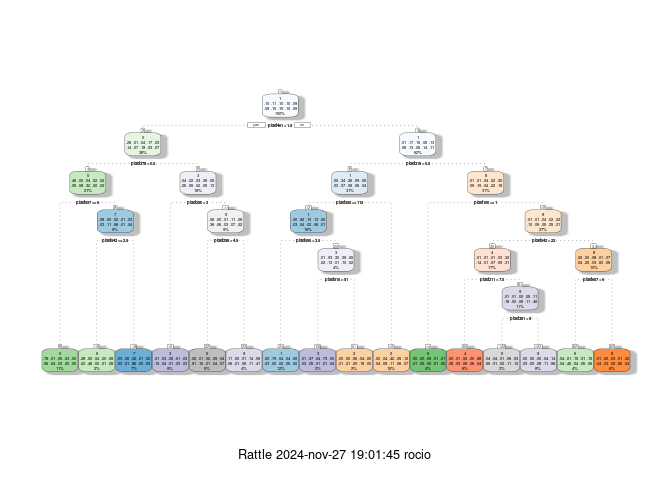

```r
fancyRpartPlot(arbol)
```

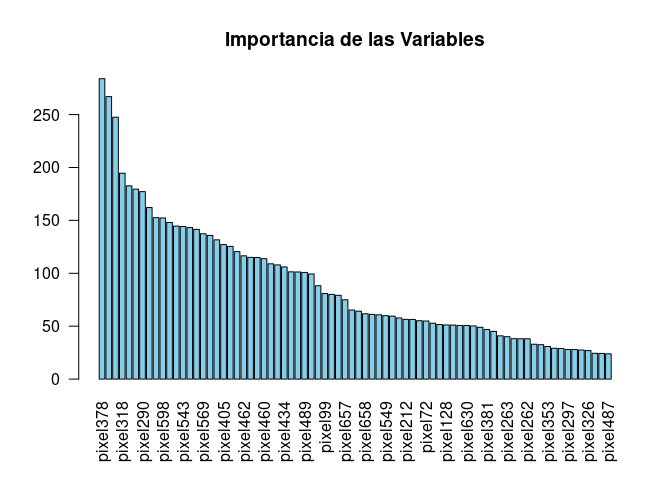

```r
barplot(arbol$variable.importance, main = "Importancia de las Variables",
        col = "skyblue", las = 2)
```

### Random Forest

El código entrena dos modelos de Random Forest con 10 y 5 árboles, respectivamente, utilizando el conjunto de datos de entrenamiento. Luego, se realizan predicciones sobre el conjunto de prueba y se calcula la precisión de cada modelo comparando las etiquetas predichas con las reales mediante una matriz de confusión.

Además, se visualiza la importancia de las variables en el modelo con 10 árboles y se compara gráficamente la precisión de ambos modelos, lo que permite evaluar cómo el número de árboles influye en el rendimiento del Random Forest.

Las precisiones obtenidas son 84,3% para diez arboles y 77,9% para cinco.

```r
forest10 <- randomForest(label ~ ., data = dtrain, ntree = 10, nodesize = 50)

pred_rf10 <- predict(forest10, newdata = dtest)
conf_matrix_rf10 <- table(Predicted = pred_rf10, Actual = dtest$label)
precision_rf10 <- sum(diag(conf_matrix_rf10)) / sum(conf_matrix_rf10)

cat("Precisión del Random Forest con 10 árboles:", precision_rf10, "\n")
```

```
## Precisión del Random Forest con 10 árboles: 0.843
```

```r
forest5 <- randomForest(label ~ ., data = dtrain, ntree = 5, nodesize = 50)

pred_rf5 <- predict(forest5, newdata = dtest)
conf_matrix_rf5 <- table(Predicted = pred_rf5, Actual = dtest$label)
precision_rf5 <- sum(diag(conf_matrix_rf5)) / sum(conf_matrix_rf5)

cat("Precisión del Random Forest con 5 árboles:", precision_rf5, "\n")
```

```
## Precisión del Random Forest con 5 árboles: 0.779
```

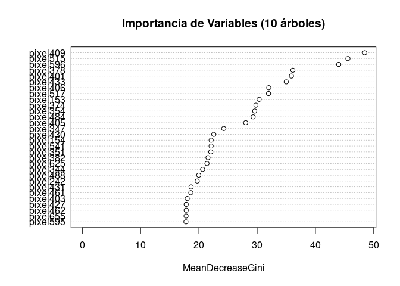

```r
varImpPlot(forest10, main = "Importancia de Variables (10 árboles)")
```

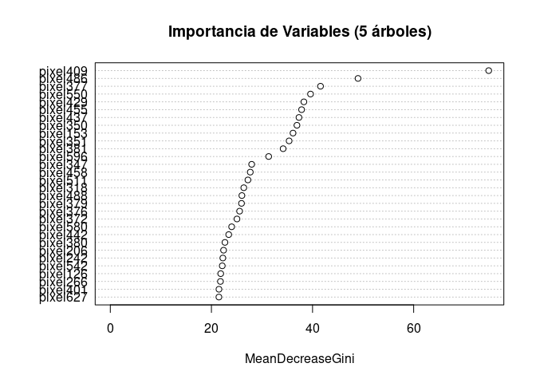

```r
varImpPlot(forest5, main = "Importancia de Variables (5 árboles)")
```

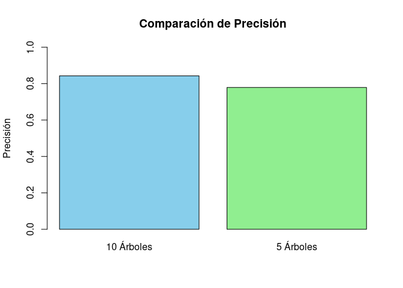

```r
barplot(
  c(precision_rf10, precision_rf5),
  names.arg = c("10 Árboles", "5 Árboles"),
  col = c("skyblue", "lightgreen"),
  main = "Comparación de Precisión",
  ylim = c(0, 1),
  ylab = "Precisión"
)
```

### SVM

```r
# Crear versiones temporales de los datos de entrenamiento y prueba
dtrain_temp <- dtrain[, !sapply(dtrain, function(x) length(unique(x)) == 1)]
dtest_temp <- dtest[, colnames(dtrain_temp)]

# Verificar si hay suficientes variables después de eliminar las constantes
if (ncol(dtrain_temp) > 1) {

  # Entrenar el modelo SVM
  svm_model <- ksvm(label ~ ., data = dtrain_temp, kernel = "polydot", kpar = list(degree = 3), cross = 3)

  # Realizar predicciones
  pred_svm <- predict(svm_model, dtest_temp)

  # Matriz de confusión y precisión
  conf_matrix_svm <- table(Predicted = pred_svm, Actual = dtest_temp$label)
  precision_svm <- sum(diag(conf_matrix_svm)) / sum(conf_matrix_svm)
  cat("Precisión del modelo SVM:", precision_svm, "\n")

  # Visualizar la matriz de confusión
  confusionMatrix(conf_matrix_svm)

  # Visualizar el modelo si hay solo dos características
  if (ncol(dtrain_temp) == 3) {
    plot(svm_model, data = dtrain_temp)
  }
} else {
  cat("No hay suficientes variables para entrenar el modelo después de eliminar las constantes.\n")
}
```

```
## Precisión del modelo SVM: 0.941
```

### Bagging

```r
# Entrenamiento del modelo de Bagging
bag_model <- bagging(label ~ ., data = dtrain, nbagg = 100)

# Predicción en el conjunto de prueba
pred_bag <- predict(bag_model, dtest)

# Matriz de confusión y cálculo de precisión
conf_bag <- table(Predicted = pred_bag, Actual = dtest$label)
cat("Precisión Bagging:", sum(diag(conf_bag)) / sum(conf_bag), "\n")
```

```
## Precisión Bagging: 0.916
```

### K-Vecinos más Cercanos (KNN)

```r
  train_labels <- dtrain$label
  train_data <- dtrain[, -1]
  test_labels <- dtest$label
  test_data <- dtest[, -1]
  pred_knn <- knn(train = train_data, test = test_data, cl = train_labels, k = 5)
  conf_knn <- table(Predicted = pred_knn, Actual = test_labels)
  cat("Precisión KNN:", sum(diag(conf_knn)) / sum(conf_knn), "\n")
```

```
## Precisión KNN: 0.912
```

### XGBoost

```r
  # Preprocesar los datos para XGBoost
  dtrain_xgb <- as.matrix(dtrain[, -1])  # Convertir los datos de entrenamiento a matriz
  dtest_xgb <- as.matrix(dtest[, -1])    # Convertir los datos de prueba a matriz

  # Convertir las etiquetas en formato adecuado para XGBoost
  dtrain_label <- as.numeric(dtrain$label) - 1  # Ajuste para XGBoost (empieza en 0)
  dtest_label <- as.numeric(dtest$label) - 1

  # Crear los objetos xgb.DMatrix
  dtrain_xgb_matrix <- xgb.DMatrix(data = dtrain_xgb, label = dtrain_label)
  dtest_xgb_matrix <- xgb.DMatrix(data = dtest_xgb, label = dtest_label)

  # Entrenar el modelo XGBoost
  xgb_model <- xgboost(data = dtrain_xgb_matrix, nrounds = 50, objective = "multi:softmax", num_class = length(unique(dtrain$label)))
  # Realizar predicciones
  pred_xgb <- predict(xgb_model, dtest_xgb_matrix)
  pred_xgb <- as.factor(pred_xgb)

  # Matriz de confusión y precisión
  conf_xgb <- table(Predicted = pred_xgb, Actual = dtest$label)
  cat("Precisión XGBoost:", sum(diag(conf_xgb)) / sum(conf_xgb), "\n")
```

```
## Precisión XGBoost: 0.934
```

### TEST

#### Rotación de la imagen para su representación

```r
rotate_image <- function(image_matrix) {
  t(apply(image_matrix, 2, rev))
}
```

#### Selección aleatoria de un dígito

```r
sample_idx <- sample(1:nrow(dtest), 1)
test_sample <- dtest[sample_idx, ]
actual_label <- test_sample$label
```

# Funcion para predicciones de los modelos

```r
predict_and_plot <- function(model, model_name) {
  test_sample_features <- test_sample[, -1]
  prediction <- predict(model, test_sample_features)

  # Representación gráfica del dígito
  image_matrix <- matrix(as.numeric(as.vector(test_sample_features)),
                         nrow = 28, ncol = 28, byrow = TRUE)
  image(rotate_image(image_matrix),
        main = paste(model_name, "- Real:", actual_label, "Pred:", prediction))
}
```

# Modelos

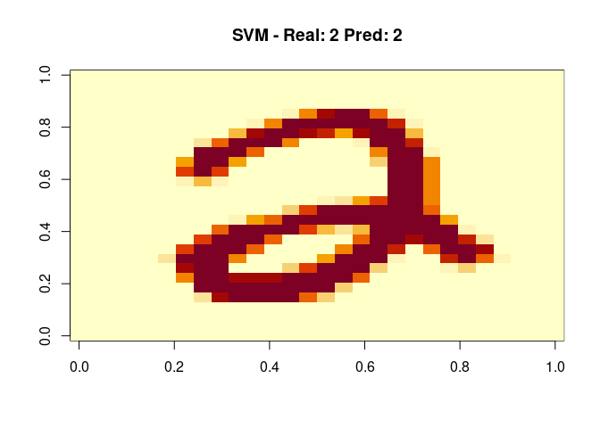

```r
# El modelo con mejor precisión
predict_and_plot(svm_model, "SVM")
```